# Symptoms - ‘NativeScript Task Dispatcher’ experiment (II)

Carlos Granell, Miguel Matey, Alberto González, Sven Casteleyn - [SyMptOMS team](http://geotec.uji.es/projects/SyMptOMS/), [GEOTEC research group](http://geotec.uji.es/)

17/4/2020 (updated 15 febrero, 2021)

This document analyses the self-developed scheduler component in Android-based mobile devices as part of the [SyMptOMS project](http://geotec.uji.es/projects/SyMptOMS/). This sofware component tested here is called [NativeScript Task Dispatcher](https://www.npmjs.com/package/nativescript-task-dispatcher), that’s a [NativeScript](https://nativescript.org/) plugin aimed to ease mobile app’s tasks definition and the execution of task workflows in background, regardless of whether the app is visible to the user or not. [NativeScript Task Dispatcher](https://www.npmjs.com/package/nativescript-task-dispatcher) is publicy available as open source software.

Required libraries and runtime environment description are as follows.

```r
library(tidyverse)
library(kableExtra)
library(here)
# library(googledrive)
library(lubridate)
library(stringr)
library(scales)
library(grid)
library(gridBase)
library(gridExtra)
# library(egg)
# library(timetk)
library(hrbrthemes)
library(viridis)
```

## Data preparation

Raw data files are cleaned and merged together into a single file stored in the folder `data`. New fields such as dates breakdown are computed too.

**Key Variables**:

- quantitative (interval)
  - `plan_date` (*datetime*): task planning time.
  - `exec_date` (*datetime*): task execution time.
- quantitative (ratio)
  - `delay` (*numeric*): execution delay in seconds ((`exec_date` - `plan_date`) - 60).
- categorital (ordinal)
  - `battery`(*numeric*): battery level
- categorical (nominal)
  - `device_id`/`device_name`: device identifier/name
  - `exp_id`: experiment identifier
  - `scheduler`: scheduler type

## Exploratory analysis

### Summary statistics

Here, we compute statistics per device and scheduler.

Table. Descriptive statistics of data distribution and centrality per scheduler/device.

| Type scheduler | Device | # records | Start | End | Min | Bottom whisker | 1st Qu. | Median | Mean | 3rd Qu. | Top whisker | Max |
| --- | --- | --- | --- | --- | --- | --- | --- | --- | --- | --- | --- | --- |
| Advanced | BQ Aquaris V | 20891 | 2021-01-25 19:04:33 | 2021-02-09 09:12:51 | -57.180 | -0.939 | -0.168 | 0.525 | 0.409 | 0.765 | 2.160 | 105.786 |
| Advanced | Honor 9 | 20008 | 2021-01-21 10:34:32 | 2021-02-04 10:46:21 | -0.946 | -0.946 | -0.731 | 0.122 | 0.226 | 1.061 | 2.312 | 2.312 |
| Advanced | Nvidia Shield Tablet | 20748 | 2021-01-25 19:04:33 | 2021-02-09 09:12:46 | -44.212 | -1.649 | -0.880 | 0.064 | 0.229 | 1.021 | 3.734 | 105.977 |
| Advanced | Xiaomi Mi A1 | 20926 | 2021-01-25 19:04:56 | 2021-02-09 09:12:20 | -61.919 | -1.644 | -0.284 | 0.234 | 0.307 | 0.770 | 2.349 | 72.190 |
| Basic | BQ Aquaris V | 20146 | 2020-04-15 11:16:26 | 2020-04-29 13:00:20 | -0.111 | 0.064 | 0.280 | 0.297 | 0.390 | 0.424 | 0.640 | 34.412 |
| Basic | Honor 9 | 21574 | 2020-03-30 12:00:03 | 2020-04-14 13:01:35 | -0.824 | -0.094 | 0.068 | 0.087 | 0.311 | 0.187 | 0.364 | 295.963 |
| Basic | Nvidia Shield Tablet | 3528 | 2020-04-15 11:16:18 | 2020-04-17 22:27:06 | -0.871 | -0.871 | 0.021 | 0.122 | 0.431 | 1.007 | 2.085 | 4.841 |
| Basic | Xiaomi Mi A1 | 10832 | 2020-04-15 11:16:23 | 2020-04-23 00:52:00 | -0.905 | -0.661 | 0.066 | 0.302 | 0.405 | 0.614 | 1.416 | 108.035 |

Now, we compute statistics per device only, that is, data points from basic and advance schedulers are aggregated together to calculate descriptive statistics.

Table. Descriptive statistics of data distribution and centrality per device only.

| Device | # records | Min | Bottom whisker | 1st Qu. | Median | Mean | 3rd Qu. | Top whisker | Max |
| --- | --- | --- | --- | --- | --- | --- | --- | --- | --- |
| BQ Aquaris V | 41037 | -57.180 | -0.310 | 0.261 | 0.303 | 0.400 | 0.642 | 1.213 | 105.786 |
| Honor 9 | 41582 | -0.946 | -0.946 | 0.057 | 0.091 | 0.270 | 0.892 | 2.138 | 295.963 |
| Nvidia Shield Tablet | 24276 | -44.212 | -1.649 | -0.338 | 0.068 | 0.258 | 1.019 | 3.042 | 105.977 |
| Xiaomi Mi A1 | 31758 | -61.919 | -1.054 | -0.007 | 0.287 | 0.340 | 0.699 | 1.757 | 108.035 |

| scheduler | device_name | n |
| --- | --- | --- |
| Advanced | BQ Aquaris V | 62 |
| Advanced | Honor 9 | 273 |
| Advanced | Nvidia Shield Tablet | 877 |
| Advanced | Xiaomi Mi A1 | 312 |
| Basic | BQ Aquaris V | 7 |
| Basic | Honor 9 | 40 |
| Basic | Nvidia Shield Tablet | 8 |
| Basic | Xiaomi Mi A1 | 11 |

[figure not shown]

### Q1: Which one of the analysed schedulers is more reliable? (Distribution of outliers)

Table. Outliers per scheduler/device.

| Device | Type scheduler | # outliers | # outliers positive | # outliers negative |
| --- | --- | --- | --- | --- |
| BQ Aquaris V | Advanced | 38 | 27 | 11 |
| BQ Aquaris V | Basic | 2992 | 2497 | 495 |
| Honor 9 | Advanced | 2 | 1 | 1 |
| Honor 9 | Basic | 5034 | 5018 | 16 |
| Nvidia Shield Tablet | Advanced | 78 | 73 | 5 |
| Nvidia Shield Tablet | Basic | 4 | 4 | NA |
| Xiaomi Mi A1 | Advanced | 217 | 115 | 102 |
| Xiaomi Mi A1 | Basic | 29 | 27 | 2 |

| scheduler | n_total |
| --- | --- |
| Advanced | 335 |
| Basic | 8059 |

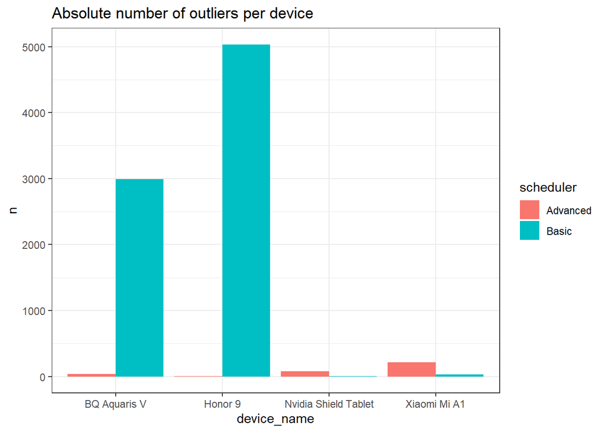

Now, statistics computed by device only

Table. Outliers per device.

| Device | Type scheduler | # outliers | # outliers positive | # outliers negative |
| --- | --- | --- | --- | --- |
| BQ Aquaris V | Advanced | 4842 | 2009 | 2833 |
| BQ Aquaris V | Basic | 20 | 20 | NA |
| Honor 9 | Advanced | 5 | 4 | 1 |
| Honor 9 | Basic | 35 | 35 | NA |
| Nvidia Shield Tablet | Advanced | 87 | 82 | 5 |
| Nvidia Shield Tablet | Basic | 1 | 1 | NA |
| Xiaomi Mi A1 | Advanced | 551 | 438 | 113 |
| Xiaomi Mi A1 | Basic | 13 | 13 | NA |

| scheduler | n_total |
| --- | --- |
| Advanced | 5485 |
| Basic | 69 |

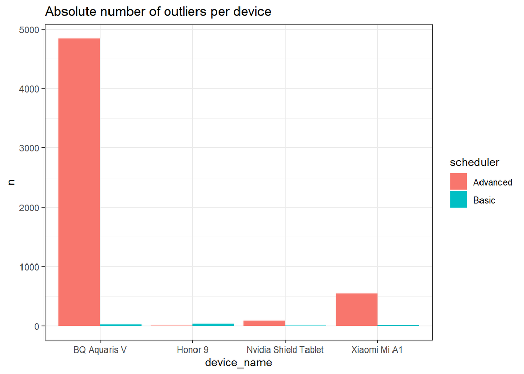

#### Centrality statistics of outliers

| scheduler | device_name | mean | median |
| --- | --- | --- | --- |
| Advanced | BQ Aquaris V | 5.092605 | 2.9819999 |
| Advanced | Honor 9 | 0.683000 | 0.6830000 |
| Advanced | Nvidia Shield Tablet | 13.163013 | 7.9085000 |
| Advanced | Xiaomi Mi A1 | 5.554802 | 2.7620001 |
| Basic | BQ Aquaris V | 0.761748 | 0.9000001 |
| Basic | Honor 9 | 1.051917 | 1.0175000 |
| Basic | Nvidia Shield Tablet | 3.123500 | 2.7840000 |
| Basic | Xiaomi Mi A1 | 10.703931 | 1.6169999 |

| scheduler | mean | median |
| --- | --- | --- |
| Advanced | 7.2447522 | 5.931 |
| Basic | 0.9799488 | 0.964 |

### Q2: Which one of the analysed schedulers is more accurate?

We assume that higher accuracy equals to lower `delay`. In Q1, we compute `delay`as `execution timestamp(i) - planned timestamp(i)`, being `i` each time step in the serie (roughly 1 minute). Here, we compute other *types* of delays to make sure that the scheduler works as expected. Therefore, we compute the following timestamps differences:

- Consecutive planning timestamps, `planned timestamp(i-1) - planned timestamp(i)`, in order to detect wrong planned timestamp values
- Consecutive execution timestamps, `execution timestamp(i-1) - execution timestamp(i)`, to detect execution timestamps between consecutive measurements
- Overhead, `execution timestamp(i) - planning timestamp(i+1)`, to explore framework overhead between consecutive measurements

#### Consecutive planning timestamps (`delay1`)

We calculate `planned timestamp(i-1) - planned timestamp(i)`, to detect wrong planning timestamp values. During data collection, chances are that some planned timestamps are not correctly registered, creating duplicated timestamps, suggested by the presence of negative values of `delay`. The new variable/metric is called `delay1`.

Table. Descriptive statistics of `delay1` (planned timestamp(i-1) - planned timestamp(i)) per scheduler/device.

| Type scheduler | Device | # records | Start | End | Min | Bottom whisker | 1st Qu. | Median | Mean | 3rd Qu. | Top whisker | Max |
| --- | --- | --- | --- | --- | --- | --- | --- | --- | --- | --- | --- | --- |
| Advanced | BQ Aquaris V | 20891 | 2021-01-25 19:04:33 | 2021-02-09 09:12:51 | -60 | -1.023 | -0.259 | 0.440 | 0.337 | 0.675 | 2.072 | 405.336 |
|  | Honor 9 | 20008 | 2021-01-21 10:34:32 | 2021-02-04 10:46:21 | -60 | -0.984 | -0.819 | 0.036 | 0.491 | 0.978 | 2.227 | 7103.945 |
|  | Nvidia Shield Tablet | 20748 | 2021-01-25 19:04:33 | 2021-02-09 09:12:46 | -60 | -1.696 | -0.932 | 0.017 | 0.753 | 0.976 | 3.812 | 12067.973 |
|  | Xiaomi Mi A1 | 20926 | 2021-01-25 19:04:56 | 2021-02-09 09:12:20 | -60 | -1.835 | -0.352 | 0.167 | 0.233 | 0.711 | 2.271 | 196.867 |
| Basic | BQ Aquaris V | 20146 | 2020-04-15 11:16:26 | 2020-04-29 13:00:20 | -60 | 0.045 | 0.247 | 0.262 | 0.351 | 0.385 | 0.591 | 34.369 |
|  | Honor 9 | 21574 | 2020-03-30 12:00:03 | 2020-04-14 13:01:35 | -60 | -0.093 | 0.014 | 0.025 | 0.243 | 0.103 | 0.235 | 236.462 |
|  | Nvidia Shield Tablet | 3528 | 2020-04-15 11:16:18 | 2020-04-17 22:27:06 | -60 | -0.887 | 0.002 | 0.098 | 0.388 | 0.979 | 2.029 | 4.777 |
|  | Xiaomi Mi A1 | 10832 | 2020-04-15 11:16:23 | 2020-04-23 00:52:00 | -60 | -0.715 | 0.009 | 0.269 | 0.352 | 0.579 | 1.429 | 108.009 |

Table. Outliers of `delay1` per scheduler/device.

| Device | Type scheduler | # outliers | # outliers positive | # outliers negative |
| --- | --- | --- | --- | --- |
| BQ Aquaris V | Advanced | 61 | 36 | 25 |
| BQ Aquaris V | Basic | 3093 | 2525 | 568 |
| Honor 9 | Advanced | 3 | 1 | 2 |
| Honor 9 | Basic | 5067 | 5048 | 19 |
| Nvidia Shield Tablet | Advanced | 79 | 68 | 11 |
| Nvidia Shield Tablet | Basic | 6 | 4 | 2 |
| Xiaomi Mi A1 | Advanced | 351 | 182 | 169 |
| Xiaomi Mi A1 | Basic | 23 | 20 | 3 |

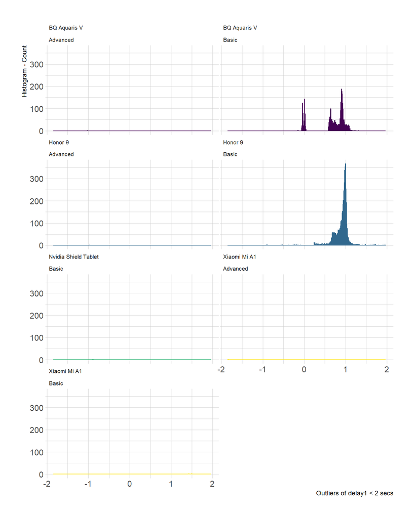

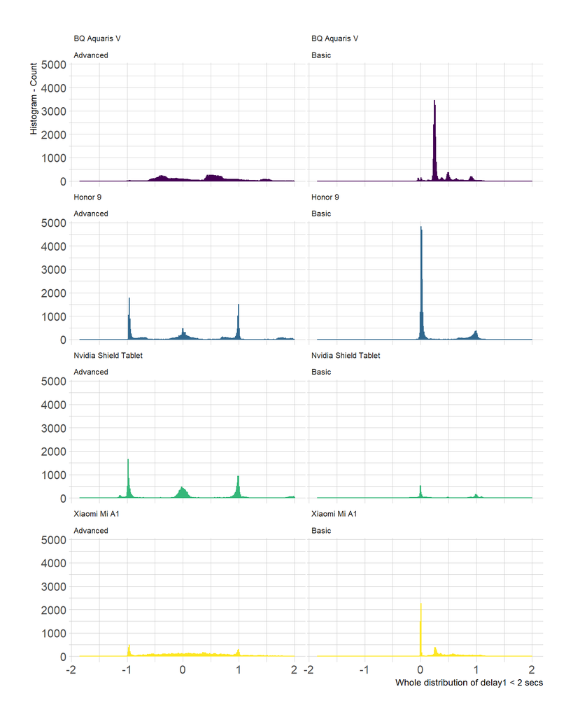

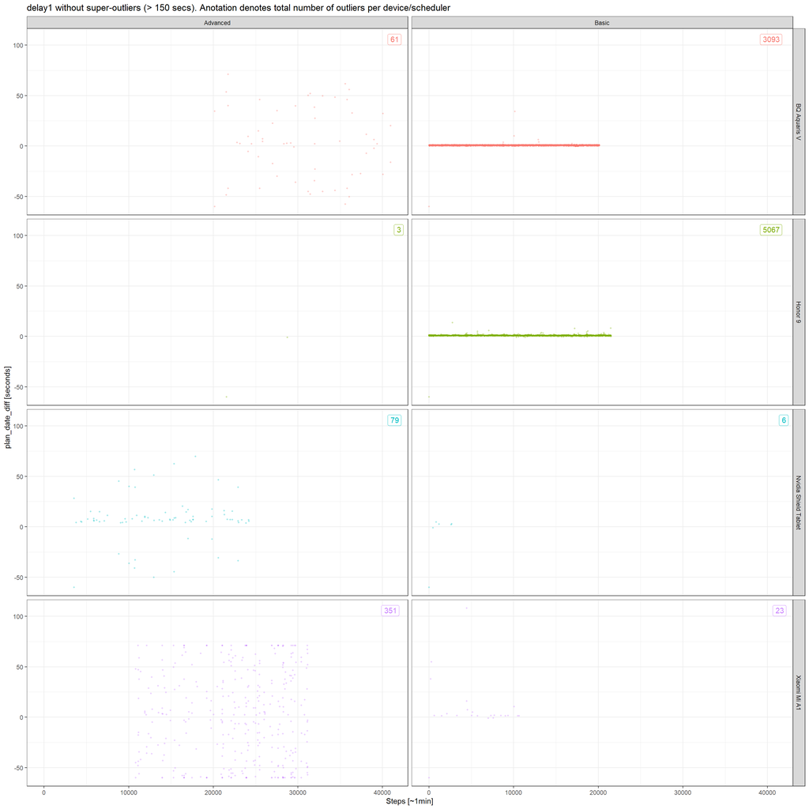

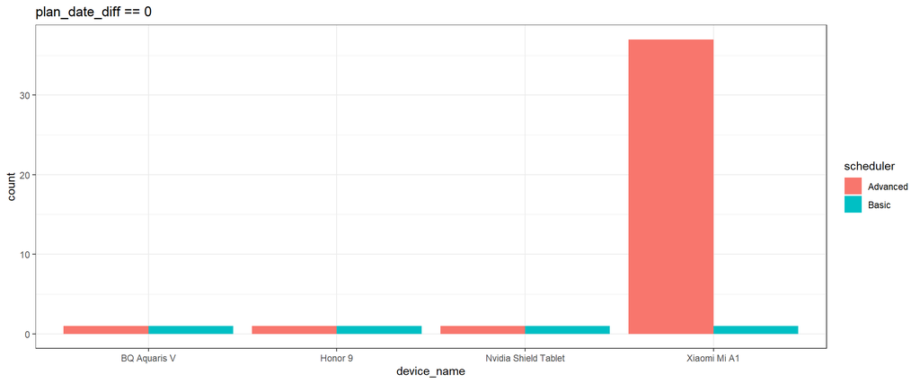

#### Consecutive execution timestamps (`delay2`)

We calculate `execution timestamp(i-1) - execution timestamp(i)` which gives us whether execution times between consecutive measurements (i.e. tasks execution) are accurate, i.e., tasks are executed as expected. The new variable/metric is called `delay2` (substracting 60 to get values around zero).

Table. Descriptive statistics of ‘delay2’ (execution timestamp(n-1) - execution timestamp(n)) per scheduler/device.

| Type scheduler | Device | # records | Start | End | Min | Bottom whisker | 1st Qu. | Median | Mean | 3rd Qu. | Top whisker | Max |
| --- | --- | --- | --- | --- | --- | --- | --- | --- | --- | --- | --- | --- |
| Advanced | BQ Aquaris V | 20891 | 2021-01-25 19:04:33 | 2021-02-09 09:12:51 | -60 | -1.241 | -0.259 | 0.439 | 0.335 | 0.676 | 2.071 | 419.805 |
| Advanced | Honor 9 | 20008 | 2021-01-21 10:34:32 | 2021-02-04 10:46:21 | -60 | -2.781 | -0.822 | 0.036 | 0.491 | 0.973 | 2.209 | 7106.083 |
| Advanced | Nvidia Shield Tablet | 20748 | 2021-01-25 19:04:33 | 2021-02-09 09:12:46 | -60 | -3.146 | -0.928 | 0.017 | 0.751 | 0.975 | 3.695 | 12070.242 |
| Advanced | Xiaomi Mi A1 | 20926 | 2021-01-25 19:04:56 | 2021-02-09 09:12:20 | -60 | -1.671 | -0.339 | 0.177 | 0.233 | 0.717 | 2.295 | 197.000 |
| Basic | BQ Aquaris V | 20146 | 2020-04-15 11:16:26 | 2020-04-29 13:00:20 | -60 | 0.043 | 0.247 | 0.262 | 0.351 | 0.383 | 0.587 | 34.369 |
| Basic | Honor 9 | 21574 | 2020-03-30 12:00:03 | 2020-04-14 13:01:35 | -60 | -0.157 | 0.010 | 0.028 | 0.243 | 0.122 | 0.290 | 295.912 |
| Basic | Nvidia Shield Tablet | 3528 | 2020-04-15 11:16:18 | 2020-04-17 22:27:06 | -60 | -0.887 | -0.003 | 0.099 | 0.388 | 0.979 | 2.062 | 4.704 |
| Basic | Xiaomi Mi A1 | 10832 | 2020-04-15 11:16:23 | 2020-04-23 00:52:00 | -60 | -0.695 | 0.021 | 0.269 | 0.352 | 0.578 | 1.402 | 108.004 |

Table. Outliers of `delay2` per scheduler/device.

| Device | Type scheduler | # outliers | # outliers positive | # outliers negative |
| --- | --- | --- | --- | --- |
| BQ Aquaris V | Advanced | 43 | 36 | 7 |
| BQ Aquaris V | Basic | 3129 | 2555 | 574 |
| Honor 9 | Advanced | 3 | 2 | 1 |
| Honor 9 | Basic | 5060 | 5023 | 37 |
| Nvidia Shield Tablet | Advanced | 90 | 77 | 13 |
| Nvidia Shield Tablet | Basic | 5 | 3 | 2 |
| Xiaomi Mi A1 | Advanced | 176 | 167 | 9 |
| Xiaomi Mi A1 | Basic | 32 | 25 | 7 |

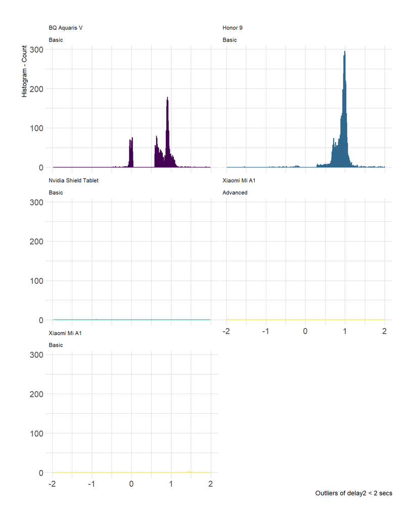

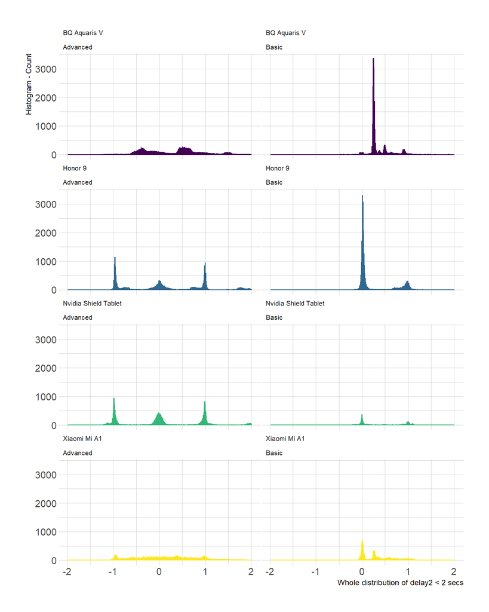